# Non-Energy drivers of CPI

2023-09-05

# Which indusries where the biggest drivers of non-energy related inflation between Februrary 2022 and February 2023?

# Install Packages and Set Directory

```r
knitr::opts_chunk$set(echo = TRUE, fig.height = 15, fig.width = 20)

# Load library function
fn_load_libraries <- function(){
  # Package names
  packages <- c(
    "rstudioapi",
    "tidyverse",
    "janitor",
    "stringr",
    "ggplot2"
  )

  # Install packages not yet installed
  installed_packages <- packages %in% rownames(installed.packages())
  if (any(installed_packages == FALSE)) {
    install.packages(packages[!installed_packages])
  }

  # Packages loading
  lapply(packages, library, character.only = TRUE)
}


# load libar
fn_load_libraries()
```

[output not shown]

```r
# Set working directory
current_dir <- dirname(rstudioapi::getSourceEditorContext()$path)
setwd(current_dir)

getwd()
```

```
## [1] "C:/Users/SHale/Documents/GitHub/Module-10-Independent-Project"
```

## Introduction

Work in this notebook is based on the ONS article on energy intensity of products and services in the CPI basket, which can be found here:

The energy intensity of the Consumer Prices Index: 2022 https://www.ons.gov.uk/economy/inflationandpriceindices/articles/theenergyintensityoftheconsumerpricesindex/2022#:~:text=We%20estimate%20that%20the%20Consumer,the%20production%20process%20of%20businesses.

There has been an increase in CPI since the middle of 2021, and an even sharper increase over the last year since the invasion of Ukraine. While the focus of the article above is on energy driven inflation, and the indirect inflation of products due to rising energy prices, we try to focus here on the non-energy related drivers of inflation. We aim to remove primary inflation due to energy, but also the indirect effect in order to access other drivers of the recent high inflation increases.

With the sharp increase in overall inflation since February 2022, lots of attention has been given to the rise in energy prices. As such, other reasons of inflation, for example because of Brexit or other policies, may have been muddied, and it is hard to distinuish other factors in the cause for high inflation.

## Read in data

First, let’s read in some data.

```r
data_dir <- paste0(current_dir, "/data/")

# file names
file_cpi_by_product <- "cpi_detailed_reference_tables_table_4.csv"
file_energy_intensity_by_product <- "CPI Energy Intensity of Household purchases, COICOP class level categories.csv"
file_cpi_cont_by_energy_intensity_class <- "Contributions to Consumer Prices Index (CPI) inflation by energy intensity, percentage points, UK, January 2019 to February 2023.csv"

# import raw data
data_cpi_by_product <- read.csv(paste0(current_dir, "/data/", file_cpi_by_product))
data_energy_intensity_by_product <- read.csv(paste0(current_dir, "/data/", file_energy_intensity_by_product))
data_cpi_cont_by_energy_intensity_class <- read.csv(paste0(current_dir, "/data/", file_cpi_cont_by_energy_intensity_class))
```

## Tidy data

```r
# tidy column names
cpi_by_product <- janitor::clean_names(data_cpi_by_product)
energy_intensity_by_product <- janitor::clean_names(data_energy_intensity_by_product)
cpi_cont_by_energy_intensity_class <- janitor::clean_names(data_cpi_cont_by_energy_intensity_class)
```

We have different sources of data which individually give information about:

1. the level of inflation for different products in the CPI ‘basket’.
2. the energy intestity for different products.
3. the contribution to inflation of products grouped into energy intensity classes (Very low, Low, High, Very high, Energy, Rents)

Initially, we are only going to look at the contribution to inflation for the 10.4% in February 2023.

First, we will consolidate the information we have into a single dataframe.

```r
df <- energy_intensity_by_product

df <- df %>% separate(coicop_class_level_item,
                      into = c("Code", "Description"),
                      sep = ":",
                      remove = TRUE) %>%
  mutate(Code = stringr::str_squish(Code),
         Description = stringr::str_squish(Description))



cpi_by_product <- cpi_by_product %>%
  mutate(coicop_class_level_item = stringr::str_squish(coicop_class_level_item)) %>%
  separate(coicop_class_level_item,
                      into = c("Code", "Description"),
                      sep = "\\s",
                      remove = FALSE,
                      extra = "merge")


cpi_by_product <- cpi_by_product %>%
  select("Code", "Description", "weights",
         "x12_month_percentage_change_nov_2022",
         "x12_month_percentage_change_dec_2022",
         "x12_month_percentage_change_jan_2023",
         "x12_month_percentage_change_feb_2023",
         "x12_month_percentage_change_mar_2023",
         "x12_month_percentage_change_apr_2023",
         "x12_month_percentage_change_may_2023",
         "x12_month_percentage_change_jun_2023",
         "x12_month_percentage_change_jul_2023",)

cpi_by_product$x12_month_percentage_change_dec_2022 <-
  as.numeric(cpi_by_product$x12_month_percentage_change_dec_2022)
cpi_by_product$x12_month_percentage_change_may_2023 <-
  as.numeric(cpi_by_product$x12_month_percentage_change_may_2023)


# df <- merge(df,
#             cpi_by_product,
#             by = "Code",
#             all.x = TRUE)

# manually amend values in cpi_by_product that are causing NAs in the merged df
cpi_by_product <- cpi_by_product %>%
  mutate(Code = case_when(
    Code == "05.3.1/2" ~ "05.3.1",
    Code == "06.1.2/3" ~ "06.1.2",
    Code == "06.2.1/3" ~ "06.2.1",
    Code == "07.1.2/3" ~ "07.1.2",
    Code == "08.2/3" ~ "08.2",
    Code == "09.2.1/2" ~ "09.2.1",
    Code == "09.3.4/5" ~ "09.3.4",
    Code == "09.5.3/4" ~ "09.5.3",
    Code == "12.1.2/3" ~ "12.1.2",
    TRUE ~ Code
  ))


df <- merge(df,
            cpi_by_product,
            by = "Code",
            all.x = TRUE)

df$x12_month_percentage_change_dec_2022 <- as.numeric(df$x12_month_percentage_change_dec_2022)
df$x12_month_percentage_change_may_2023 <- as.numeric(df$x12_month_percentage_change_may_2023)

# Table of industry codes
industry_codes <- cpi_by_product[2:13, c("Code", "Description")] %>%
  rename(Industry_Code = Code,
         Industry = Description)

# Extract the industry code form the longer product code
df <- df %>% mutate(Industry_Code = substr(Code, start = 1, stop = 2))

# Add industry code and industry description for each product
df <- merge(df,
            industry_codes,
            by = "Industry_Code",
            all.x = TRUE)
```

## Recnt CPI Inflation

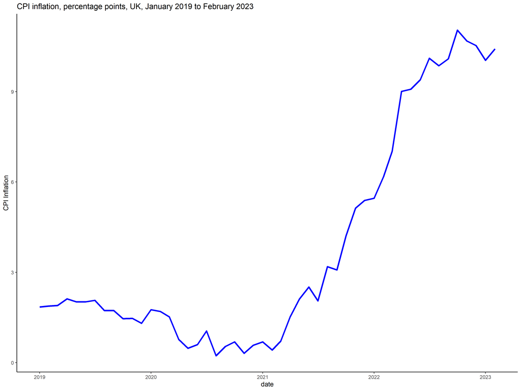

```r
cpi_cont_by_energy_intensity_class <- janitor::clean_names(data_cpi_cont_by_energy_intensity_class)

cpi_cont_by_energy_intensity_class <- cpi_cont_by_energy_intensity_class %>%
  mutate(month = str_squish(str_to_title(month)),
         total_cpi = rents + energy + very_high + high + low + very_low)


###### Want to convert month column to data format but this doesn't seem to be working !?
# cpi_cont_by_energy_intensity_class <- cpi_cont_by_energy_intensity_class %>%
#   mutate(month = as.Date(month, format = "%Y %b"))

# glimpse(cpi_cont_by_energy_intensity_class)

# For now just fudged by adding date to the csv file
######

cpi_cont_by_energy_intensity_class <- cpi_cont_by_energy_intensity_class %>%
  mutate(date = as.Date(date, format = "%d/%m/%Y"))

ggplot(cpi_cont_by_energy_intensity_class, aes(x = date, y = total_cpi)) +
  geom_line(color = "blue", linewidth = 2) +
  labs(
    title = "CPI inflation, percentage points, UK, January 2019 to February 2023 ",
    y = "CPI Inflation"
  ) +
  theme_classic(base_size = 18)
```

## Inflation February 2023

### Article’s Figure 3 data:

Data from the chart includes the amount of inflation caused by energy, rents, and different energy intensity classes.

```r
feb23_inflation <- as.data.frame(t(cpi_cont_by_energy_intensity_class %>% filter(month == "2023 Feb")))

feb23_inflation <- feb23_inflation %>%
  filter(V1 != "2023 Feb" & V1 != "2023-02-01" & V1 != "10.42") %>%
  rename(inflation_contribution = V1) %>%
  mutate(inflation_contribution = as.numeric(inflation_contribution))

print(feb23_inflation)
```

```
##           inflation_contribution
## rents                       0.40
## energy                      3.28
## very_high                   2.00
## high                        2.52
## low                         1.05
## very_low                    1.17
```

```r
total_inflation <- sum(feb23_inflation$inflation_contribution)
print(total_inflation)
```

```
## [1] 10.42
```

This is the 10.4% increase in CPI we see given in Figure 3 of the article.

Looking at the relative proportions of the different classes:

```r
feb23_inflation <- feb23_inflation %>%
  mutate(inflation_contribution_ppn = inflation_contribution/total_inflation,
         inflation_contribution_pct = round(100*inflation_contribution_ppn,1))

print(feb23_inflation)
```

```
##           inflation_contribution inflation_contribution_ppn
## rents                       0.40                 0.03838772
## energy                      3.28                 0.31477927
## very_high                   2.00                 0.19193858
## high                        2.52                 0.24184261
## low                         1.05                 0.10076775
## very_low                    1.17                 0.11228407
##           inflation_contribution_pct
## rents                            3.8
## energy                          31.5
## very_high                       19.2
## high                            24.2
## low                             10.1
## very_low                        11.2
```

### Calculating contribution to inflation for each product in our df

In our products df, the ‘weights’ column gives the weight, out of 1000, that each product contributes in the basket of goods towards inflation. By multiplying the relative weight of each product by it’s increase in price we can obtain the gross contribution to overall inflation for each product.

```r
df <- df %>%
  mutate(weight_proportion = weights/1000,
         inflation_contribution = x12_month_percentage_change_feb_2023 * weight_proportion)

head(df)
```

```
##   Industry_Code   Code       Description.x energy_intensity
## 1            01 01.1.1     BREAD & CEREALS            0.020
## 2            01 01.1.2                MEAT            0.019
## 3            01 01.1.3                FISH            0.023
## 4            01 01.1.4 MILK, CHEESE & EGGS            0.018
## 5            01 01.1.5         OILS & FATS            0.021
## 6            01 01.1.6               FRUIT            0.032
##   energy_intensity_group         Description.y weights
## 1                   High     Bread and cereals      21
## 2                   High                  Meat      20
## 3                   High                  Fish       5
## 4                   High Milk, cheese and eggs      14
## 5                   High         Oils and fats       4
## 6              Very high                 Fruit      10
##   x12_month_percentage_change_nov_2022 x12_month_percentage_change_dec_2022
```

[output cut: 41 more lines]

```r
df_total_inflation <- sum(df$inflation_contribution)
print(df_total_inflation)
```

```
## [1] 12.3647
```

This is coming out higher than the 10.4% expected. This may be due to not all products mapping over completely from the detailed reference table to the data by energy intensity class level. Additionally, it seems the relative weight of the subcategories do not necessarily add up totally to the overall inflation. For example, using this method and summing the gross inflation of the 12 industry areas - Code ‘01’ to ‘12’ - gives a value of 10.7% compared to the overall figure of 10.4%:

```r
head(cpi_by_product, 13)
```

```
##    Code                                      Description weights
## 1   CPI                                  (overall index)    1000
## 2    01                 Food and non-alcoholic beverages     119
## 3    02                  Alcoholic beverages and tobacco      42
## 4    03                            Clothing and footwear      58
## 5    04 Housing, water, electricity, gas and other fuels     141
## 6    05   Furniture, household equipment and maintenance      68
## 7    06                                           Health      24
## 8    07                                        Transport     137
## 9    08                                    Communication      23
## 10   09                           Recreation and culture     138
## 11   10                                        Education      29
## 12   11                           Restaurants and hotels     138
## 13   12                 Miscellaneous goods and services      83
##    x12_month_percentage_change_nov_2022 x12_month_percentage_change_dec_2022
```

[output cut: 69 more lines]

```r
sum((cpi_by_product$weights[2:13]/1000) * cpi_by_product$x12_month_percentage_change_feb_2023[2:13])
```

```
## [1] 10.7014
```

In order to make further analysis easier, we will use the relative contributions to overall inflation that we have found in df, and scale the gross contributions so that they total 10.42%:

```r
df <- df %>%
  mutate(inflation_contribution_scaled = inflation_contribution *
                                              total_inflation/df_total_inflation)

# check
sum(df$inflation_contribution_scaled)
```

```
## [1] 10.42
```

## Non-Energy inflation

We now want to analyse the biggest drivers of inflation other than energy, and see which industries are affected most by non-energy related factors. To do this we will strip out any products that are direct energy drivers, as well as indirect energy driven inflation by using the energy intensity of products.

### Explore the data

First, let’s look at a current summary of our data.

By energy intensity class…

```r
df_summary1 <- df %>%
  group_by(energy_intensity_group) %>%
  summarise(Count = n(),
            Total_infl = sum(inflation_contribution_scaled),
            Percentage = round(100 * sum(inflation_contribution_scaled) /
                               sum(df$inflation_contribution_scaled), 1 ))

df_summary1
```

```
## # A tibble: 6 × 4
##   energy_intensity_group Count Total_infl Percentage
##   <chr>                  <int>      <dbl>      <dbl>
## 1 Energy                     4      3.84        36.8
## 2 High                      25      2.29        22
## 3 Low                       23      0.939        9
## 4 Rents                      1      0.313        3
## 5 Very high                 12      1.93        18.5
## 6 Very low                  19      1.11        10.7
```

…and by industry…

```r
df_summary2 <- df %>%
  group_by(Industry_Code, Industry) %>%
  summarise(Count = n(),
            Total_infl = sum(inflation_contribution_scaled),
            Percentage = round(100 * sum(inflation_contribution_scaled) /
                               sum(df$inflation_contribution_scaled), 1 ),
            Ave_energy_intensity = mean(energy_intensity))
df_summary2
```

```
## # A tibble: 12 × 6
## # Groups:   Industry_Code [12]
##    Industry_Code Industry       Count Total_infl Percentage Ave_energy_intensity
##    <chr>         <chr>          <int>      <dbl>      <dbl>                <dbl>
##  1 01            Food and non-…    11     1.84         17.7              0.0204
##  2 02            Alcoholic bev…     4     0.202         1.9              0.01
##  3 03            Clothing and …     4     0.393         3.8              0.00575
##  4 04            Housing, wate…     9     4.10         39.4              0.219
##  5 05            Furniture, ho…     9     0.503         4.8              0.0147
##  6 06            Health             5     0.135         1.3              0.013
##  7 07            Transport         10     0.566         5.4              0.103
##  8 08            Communication      2     0.0693        0.7              0.0175
##  9 09            Recreation an…    16     0.645         6.2              0.0136
## 10 10            Education          1     0.0782        0.8              0.01
## 11 11            Restaurants a…     3     1.41         13.5              0.0277
## 12 12            Miscellaneous…    10     0.478         4.6              0.0083
```

### Overall CPI energy intensity

Using the weights and the energy intensity provided we should be able to recreate the CPI energy intensity of 6.6% given in the article.

```r
CPI_energy_intensity <- round(100*sum(df$weights * df$energy_intensity) / sum(df$weights), 2)
CPI_energy_intensity
```

```
## [1] 6.52
```

This looks reasonable.

### Remove CPI divisions that contain direct energy components

These are marked as being in the ‘Energy’ category in the Figure 3 data. These are “ELECTRICITY”, “GAS”, “LIQUID FUELS” and “FUELS & LUBRICANTS”. They have an energy intensity between 57.2% and 68%, suggesting that there are some non-energy related contribution to inflation for these products. However, we will choose to remove them going forward.

```r
df_non_energy <- df %>%
  filter(energy_intensity_group != "Energy")

CPI_energy_intensity_excl_energy <- round(100*sum(df_non_energy$weights * df_non_energy$energy_intensity) /
                                                              sum(df_non_energy$weights), 1)

print("Overall energy intensity, excluding CPI divisions that contain direct energy components:")
```

```
## [1] "Overall energy intensity, excluding CPI divisions that contain direct energy components:"
```

```r
CPI_energy_intensity_excl_energy
```

```
## [1] 1.6
```

### Remove Indirect Energy inflation

Now, for products which do not contain direct energy components, we want to calculate the indirect energy inflation and remove it.

We first split the contribution to inflation for each product into energy effected (indirect energy inflation) and non-energy effected. We can then look at the non-energy effected inflation on its own.

```r
df_non_energy <- df_non_energy %>%
  mutate(energy_inflation = inflation_contribution_scaled * energy_intensity,
         non_energy_inflation = inflation_contribution_scaled * (1-energy_intensity))

# sum(df_non_energy$inflation_contribution_scaled)
print("Total inflation for February 2023 that is due to the indirect effect of energy price increase:")
```

```
## [1] "Total inflation for February 2023 that is due to the indirect effect of energy price increase:"
```

```r
sum(df_non_energy$energy_inflation)
```

```
## [1] 0.1227685
```

```r
print("Percentage of total inflation for February 2023 that is due to the indirect effect of energy price increase:")
```

```
## [1] "Percentage of total inflation for February 2023 that is due to the indirect effect of energy price increase:"
```

```r
round(100 * sum(df_non_energy$energy_inflation)/total_inflation, 2)
```

```
## [1] 1.18
```

```r
print("Total inflation for February 2023 that is neither direct or indirect energy related:")
```

```
## [1] "Total inflation for February 2023 that is neither direct or indirect energy related:"
```

```r
sum(df_non_energy$non_energy_inflation)
```

```
## [1] 6.462005
```

```r
# 100 * sum(df_non_energy$energy_inflation)/sum(df_non_energy$inflation_contribution_scaled)

print("Percentage of total inflation for February 2023 that is neither direct or indirect energy related:")
```

```
## [1] "Percentage of total inflation for February 2023 that is neither direct or indirect energy related:"
```

```r
round(100 * sum(df_non_energy$non_energy_inflation)/total_inflation, 2)
```

```
## [1] 62.02
```

This suggests that 62% of the 12 month inflation in Feb 2023 was driven by non-energy and non-indirect energy effects, and that only 1% of inflation was driven by the indirect impact of rising energy prices on non-energy products and services.

```r
df_summary3 <- df_non_energy %>%
  group_by(Industry_Code, Industry) %>%
  summarise(Count = n(),
            total_inflation = round(sum(non_energy_inflation), 2),
            Percentage = round(100 * sum(non_energy_inflation) /
                               sum(df_non_energy$non_energy_inflation), 1 ),

            )
df_summary3
```

```
## # A tibble: 12 × 5
## # Groups:   Industry_Code [12]
##    Industry_Code Industry                       Count total_inflation Percentage
##    <chr>         <chr>                          <int>           <dbl>      <dbl>
##  1 01            Food and non-alcoholic bevera…    11            1.81       27.9
##  2 02            Alcoholic beverages and tobac…     4            0.2         3.1
##  3 03            Clothing and footwear              4            0.39        6.1
##  4 04            Housing, water, electricity, …     6            0.38        6
##  5 05            Furniture, household equipmen…     9            0.5         7.7
##  6 06            Health                             5            0.13        2.1
##  7 07            Transport                          9            0.43        6.6
##  8 08            Communication                      2            0.07        1.1
##  9 09            Recreation and culture            16            0.64        9.9
## 10 10            Education                          1            0.08        1.2
## 11 11            Restaurants and hotels             3            1.37       21.2
## 12 12            Miscellaneous goods and servi…    10            0.47        7.3
```

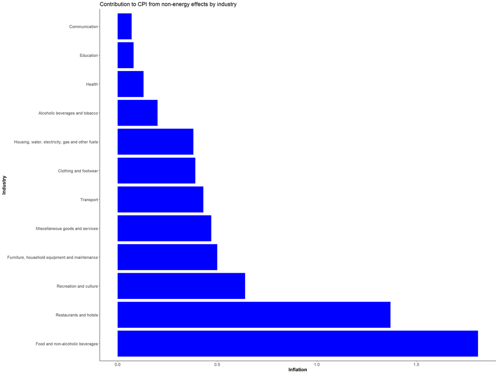

```r
ggplot(df_summary3, aes(x = reorder(Industry, -total_inflation), y = total_inflation)) +
  geom_bar(stat = "identity", fill = "blue") +
  labs(title = "Contribution to CPI from non-energy effects by industry",
       x = "Industry",
       y = "Inflation") +
  coord_flip() +
  theme_classic() +  # Horizontal orientation
  theme(
    plot.title = element_text(size = 16),  # Increase title size
    axis.title.x = element_text(size = 14, face = "bold"),  # Increase x-axis label size
    axis.title.y = element_text(size = 14, face = "bold"),   # Increase y-axis label size
    axis.text.x = element_text(size = 12),
    axis.text.y = element_text(size = 12)
  )
```

### Largest drivers of inflation (Products and Services)

```r
largest_drivers <- df_non_energy %>%
  arrange(desc(non_energy_inflation)) %>%
  select(9, 3, 4, 5, 14)

head(largest_drivers, 10)
```

```
##    x12_month_percentage_change_dec_2022
## 1                                  10.1
## 2                                  16.3
## 3                                  30.2
## 4                                   4.6
## 5                                   6.9
## 6                                  10.5
## 7                                  15.1
## 8                                  15.5
## 9                                  14.9
## 10                                 11.9
##                                     Description.x energy_intensity
## 1                             RESTAURANTS & CAFES            0.026
## 2                          ACCOMMODATION SERVICES            0.031
## 3                             MILK, CHEESE & EGGS            0.018
```

[output cut: 18 more lines]

## Non-energy inflation through time [STILL A WORK IN PROGRESS]

Let’s expand our energy vs non-energy calculation for all teh last 9 months which we have in our cpi_by_product dataset.

```r
overall_cpi <- c(cpi_by_product[[4]][[1]],
                 cpi_by_product[[5]][[1]],
                 cpi_by_product[[6]][[1]],
                 cpi_by_product[[7]][[1]],
                 cpi_by_product[[8]][[1]],
                 cpi_by_product[[9]][[1]],
                 cpi_by_product[[10]][[1]],
                 cpi_by_product[[11]][[1]],
                 cpi_by_product[[12]][[1]])

x12_cols <- colnames(df)[8:16]

for (col_name in x12_cols) {

  # create the inflation contribution for each product for each month usign the price increases and weights
  infl_cont_col_name <- paste0(str_sub(col_name, start = 29, end = 36), "_infl_cont")
  df[infl_cont_col_name] <- df[[col_name]] * df[["weight_proportion"]]

  col_sum <- sum(df[infl_cont_col_name], na.rm=TRUE)

  # scale so that the total contributions equals the recorded overall cpi
  infl_cont_col_name_scaled <- paste0(str_sub(col_name, start = 29, end = 36), "_infl_cont_scaled")

  index <- which(x12_cols == col_name)
  df[infl_cont_col_name_scaled] <- df[infl_cont_col_name] *
                              (overall_cpi[[index]] / sum(df[infl_cont_col_name], na.rm = TRUE ))


}

# scaled_cols <- colnames(df)[30:38]
#
# for (col_names in scaled_cols) {
#
#   # create the energy and non-energy inflation for each month
#   col_name_energy <- paste0(str_sub(col_name, start = 29, end = 36), "_energy")
#   df[col_name_energy] <- df[col_names] * df[energy_intensity]
#
#
# }


######## Couldn't get the above loop working so long winded below
df <- df %>%
  mutate(
    nov_2022_energy = nov_2022_infl_cont_scaled * energy_intensity,
    dec_2022_energy = dec_2022_infl_cont_scaled * energy_intensity,
    jan_2023_energy = jan_2023_infl_cont_scaled * energy_intensity,
    feb_2023_energy = feb_2023_infl_cont_scaled * energy_intensity,
    mar_2023_energy = mar_2023_infl_cont_scaled * energy_intensity,
    apr_2023_energy = apr_2023_infl_cont_scaled * energy_intensity,
    may_2023_energy = may_2023_infl_cont_scaled * energy_intensity,
    jun_2023_energy = jun_2023_infl_cont_scaled * energy_intensity,
    jun_2023_energy = jul_2023_infl_cont_scaled * energy_intensity
    ) %>%
  mutate(
    nov_2022_non_energy = nov_2022_infl_cont_scaled - nov_2022_energy,
    dec_2022_non_energy = dec_2022_infl_cont_scaled - dec_2022_energy,
    jan_2023_non_energy = jan_2023_infl_cont_scaled - jan_2023_energy,
    feb_2023_non_energy = feb_2023_infl_cont_scaled - feb_2023_energy,
    mar_2023_non_energy = mar_2023_infl_cont_scaled - mar_2023_energy,
    apr_2023_non_energy = apr_2023_infl_cont_scaled - apr_2023_energy,
    may_2023_non_energy = may_2023_infl_cont_scaled - may_2023_energy,
    jun_2023_non_energy = jun_2023_infl_cont_scaled - jun_2023_energy,
    jun_2023_non_energy = jul_2023_infl_cont_scaled - jun_2023_energy
  )
```

```r
df_summary4 <- data.frame(month = c("2022-11-01",
                                    "2022-12-01",
                                    "2023-01-01",
                                    "2023-02-01",
                                    "2023-03-01",
                                    "2023-04-01",
                                    "2023-05-01",
                                    "2023-06-01",
                                    "2023-07-01"
                                    ))

df_summary4 <- df_summary4 %>%
  mutate(
    total_inflation = c(
      sum(df$nov_2022_infl_cont_scaled, na.rm=TRUE),
      sum(df$dec_2022_infl_cont_scaled, na.rm=TRUE),
      sum(df$jan_2023_infl_cont_scaled, na.rm=TRUE),
      sum(df$feb_2023_infl_cont_scaled, na.rm=TRUE),
      sum(df$mar_2023_infl_cont_scaled, na.rm=TRUE),
      sum(df$apr_2023_infl_cont_scaled, na.rm=TRUE),
      sum(df$may_2023_infl_cont_scaled, na.rm=TRUE),
      sum(df$jun_2023_infl_cont_scaled, na.rm=TRUE),
      sum(df$jul_2023_infl_cont_scaled, na.rm=TRUE)),

    energy_inflation = c(
      sum(df$nov_2022_energy, na.rm=TRUE),
      sum(df$dec_2022_energy, na.rm=TRUE),
      sum(df$jan_2023_energy, na.rm=TRUE),
      sum(df$feb_2023_energy, na.rm=TRUE),
      sum(df$mar_2023_energy, na.rm=TRUE),
      sum(df$apr_2023_energy, na.rm=TRUE),
      sum(df$may_2023_energy, na.rm=TRUE),
      sum(df$jun_2023_energy, na.rm=TRUE),
      sum(df$jul_2023_energy, na.rm=TRUE)),

    non_energy_inflation = c(
      sum(df$nov_2022_non_energy, na.rm=TRUE),
      sum(df$dec_2022_non_energy, na.rm=TRUE),
      sum(df$jan_2023_non_energy, na.rm=TRUE),
      sum(df$feb_2023_non_energy, na.rm=TRUE),
      sum(df$mar_2023_non_energy, na.rm=TRUE),
      sum(df$apr_2023_non_energy, na.rm=TRUE),
      sum(df$may_2023_non_energy, na.rm=TRUE),
      sum(df$jun_2023_non_energy, na.rm=TRUE),
      sum(df$jul_2023_non_energy, na.rm=TRUE))

  )
```

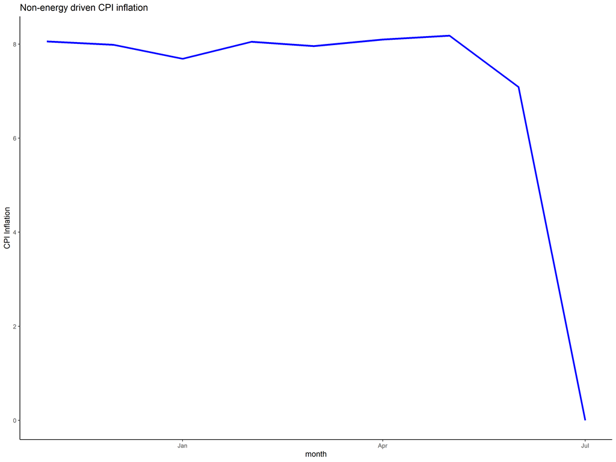

```r
df_summary4$month <- as.Date(df_summary4$month)

ggplot(df_summary4, aes(x = month, y = non_energy_inflation)) +
  geom_line(color = "blue", linewidth = 2) +

  labs(
    title = "Non-energy driven CPI inflation",
    y = "CPI Inflation"
  ) +
  theme_classic(base_size = 18)
```

```r
###### plot total inflation, energy inflation and non-energy inflation on single chart...


# ...
# ...
```